## Overview

### Basic anatomy of a function

```r
my_fun <- function(arg1, arg2) {
  body
}
```

### Example: Circumference of a circle

The circumference of a circle is $2\pi r$ for a given radius, r. Let’s write a function called `circumference` that performs this calculation for any given radius.

```r
# Define circumference() here
circumference <- function(r) {
  2 * pi * r
}
circumference(3)
```

```
## [1] 18.84956
```

### Example: Dealing cards

The below code defines a standard 52-card deck.

```r
deck <- as.vector(outer(c("A",2:10,"J","Q","K"), c("\u2660","\u2665","\u2666", "\u2663"), paste0))
deck
```

```
##  [1] "A♠"  "2♠"  "3♠"  "4♠"  "5♠"  "6♠"  "7♠"  "8♠"  "9♠"  "10♠" "J♠"
## [12] "Q♠"  "K♠"  "A♥"  "2♥"  "3♥"  "4♥"  "5♥"  "6♥"  "7♥"  "8♥"  "9♥"
## [23] "10♥" "J♥"  "Q♥"  "K♥"  "A♦"  "2♦"  "3♦"  "4♦"  "5♦"  "6♦"  "7♦"
## [34] "8♦"  "9♦"  "10♦" "J♦"  "Q♦"  "K♦"  "A♣"  "2♣"  "3♣"  "4♣"  "5♣"
## [45] "6♣"  "7♣"  "8♣"  "9♣"  "10♣" "J♣"  "Q♣"  "K♣"
```

Let’s write a function called `deal` that deals an `n` card hand from a deck, `x`.

```r
# Define deal() here
deal <- function(x, n) {
  sample(x, size = n)
}
```

Run the below code to deal a 5-card hand and a 13-card hand:

```r
deal(deck, n = 5)
```

```
## [1] "4♥"  "4♣"  "6♠"  "10♥" "9♣"
```

```r
deal(deck, n = 13)
```

```
##  [1] "A♠"  "2♣"  "7♥"  "10♣" "K♠"  "Q♥"  "8♠"  "5♣"  "4♣"  "8♦"  "4♠"
## [12] "9♦"  "2♦"
```

```r
# Alter deal() so that n = 5 by default
deal <- function(x, n = 5) {
  sample(x, size = n)
}
```

What happens if we run the below code?

```r
deal(deck)
```

```
## [1] "9♦" "Q♥" "3♦" "K♥" "Q♣"
```

## Your turn: Gambler’s ruin

Below is the code we wrote to simulate one trial in the gambler’s ruin problem. Write a function called `gamblers_ruin` that takes `N` (total wealth), `p` (probability that A wins), and `i` (A’s initial wealth) as inputs and returns the number of bets until one player is ruined.

```r
# Functionalize the below code
gamblers_ruin <- function(N, p, i) {

  bets <- 0 # initializing no. of bets

  while(i > 0 & (N - i) > 0) {
    bets <- bets + 1
    outcome <- rbinom(1, n = 1, p = p)
    if (outcome == 1) {
      i <- i + 1
    } else {
      i <- i - 1
    }
  }

  return(bets)

}
```

```r
# Test gamblers_ruin() here
N <- 20   # set total wealth
p <- 0.5  # set prob. A wins a bet
i <- 10   # A's initial wealth

gamblers_ruin(N = 100, p= 0.5, i = 10)
```

```
## [1] 208
```

Writing a function to perform the simulation allows us to easily replicate it’s output many times. In this situation, we can use the `replicate` function to quickly run our function 1,000 times.

```r
our_sim <- replicate(n = 1000, expr = gamblers_ruin(N = 20, p = .5, i = 10))
head(our_sim)
```

```
## [1] 198  78  54 108  30  98
```

Then we can easily calculate the expected number of bets required for one player to be ruined.

```r
mean(our_sim)
```

```
## [1] 97.318
```

We can also plot the simulation results

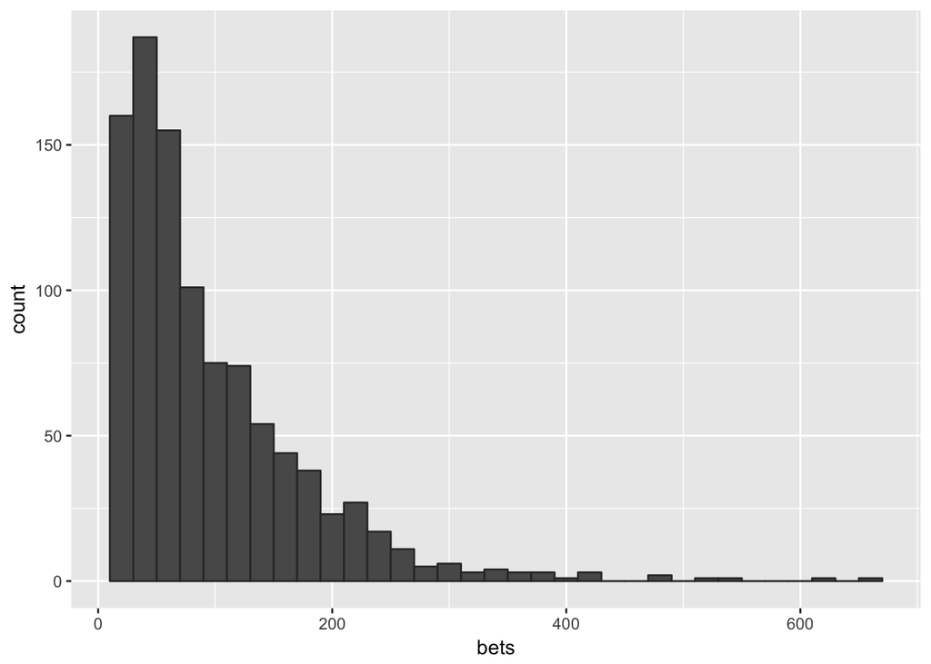

```r
library(tidyverse)
ggplot(data = data.frame(bets = our_sim), aes(x = bets)) +
  geom_histogram(color = "gray20", binwidth = 20)
```

## Your turn: One-sample bootstrap for the median

Below is the code we wrote last class to carryout the one-sample bootstrap for the sample median based on `our_sample`. Write a function called `bootstrap_median` that performs this bootstrap and returns the medians.

Take a vector, `x`, and the number of bootstrap resamples, `B`, as inputs.

```r
# Load the libraries
library(tidyverse)

# Read in the data sets
sf2016 <- read_csv("https://github.com/cmsc205/notes/raw/master/day18/sf2016.csv")

# Take a random sample from the population
our_sample <- sf2016 %>%
  sample_n(size = 500)

# Below is the code for bootstrapping the sample median
B <- 5000 # No. of bootstrap statsistics desired
n <- nrow(our_sample)
medians <- numeric(length = B) # Place to store the stats
for(b in 1:B) {
  boot_sample <- sample(our_sample$TotalCompensation,
                        size = n,
                        replace = TRUE)
  medians[b] <- median(boot_sample)
}
```

```r
# Define bootstrap_median() here
bootstrap_median <- function(x, B){
  n <- length(x)
  medians <- numeric(length = B)
  for(b in 1:B) {
    boot_sample <- sample(x,
                          size = n,
                          replace = TRUE)
    medians[b] <- median(boot_sample)
  }
  medians
}
```

```r
# Let's test the function
med1 <- bootstrap_median(our_sample$TotalCompensation, B = 5000)

str(med1)
```

```
##  num [1:5000] 112031 108315 113976 107438 105482 ...
```

```r
summary(med1)
```

```
##    Min. 1st Qu.  Median    Mean 3rd Qu.    Max.
##   93530  103200  106500  106900  111600  122700
```

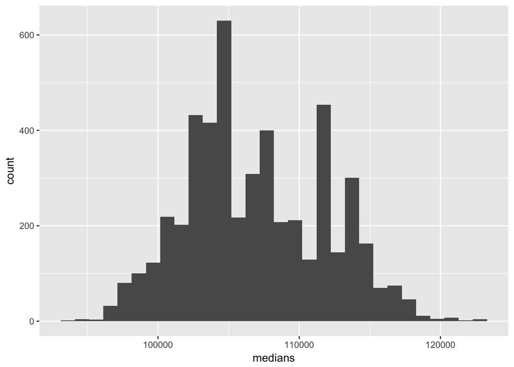

```r
ggplot(data = data.frame(medians = med1),
       aes(x = medians)) +
  geom_histogram()
```

## Your turn: One-sample bootstrap for the mean

Once you have written `bootstrap_median` it’s easy to extend what you have learned to other one-sample bootstraps.

Write a function called `bootstrap_mean` that performs this bootstrap and returns the means Take a vector, `x`, and the number of bootstrap resamples, `B`, as inputs.

```r
# Define bootstrap_mean() here
bootstrap_mean <- function(x, B){
  n <- length(x)
  means <- numeric(length = B)
  for(b in 1:B) {
    boot_sample <- sample(x,
                          size = n,
                          replace = TRUE)
    means[b] <- mean(boot_sample)
  }
  means
}

mean1 <- bootstrap_mean(our_sample$TotalCompensation, B = 10000)

summary(mean1)
```

```
##    Min. 1st Qu.  Median    Mean 3rd Qu.    Max.
##   94580  104400  106600  106600  108800  119300
```

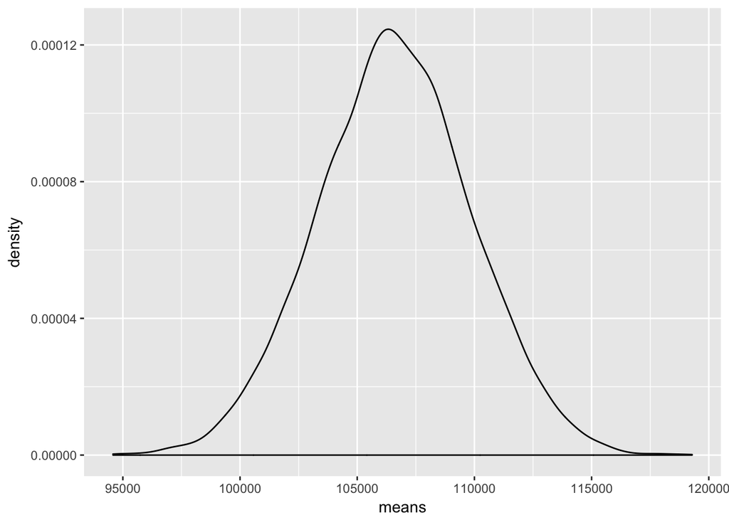

```r
ggplot(data = data.frame(means = mean1),
       aes(x = means)) +
  geom_density()
```

Now that you have written two one-sample bootstrap functions, compare your code. How many of the commands are the same? Did it feel like you were simply copying and pasting?

## Using a function as an argument

The only differences between `bootstrap_median` and `bootstrap_mean` are the statistics calculate from each sample, which resulted in a lot of repetition between the two functions. An alternative to writing different bootstrapping functions for different statistics is to specify the function of interest as an argument to a more general function.

Let’s write a single `bootstrap1` function that conducts a one-sample bootstrap on a vector, `x`. We’ll use the `stat` argument to specify the statistic of interest, and `B` to denote the number of bootstrap samples desired.

```r
# Define the bootstrap1() function here
bootstrap1 <- function(x, B, stat){
  n <- length(x)
  stats <- numeric(length = B)
  for(b in 1:B) {
    boot_sample <- sample(x,
                          size = n,
                          replace = TRUE)
    stats[b] <- stat(boot_sample)
  }
  stats
}
```

Let’s see how it works on the `our_sample` data.

```r
boot_medians <- bootstrap1(our_sample$TotalCompensation,
                           stat = median, B = 5000)

head(boot_medians)
```

```
## [1] 113554.1 106537.7 111672.6 107943.5  99076.1 107691.0
```

```r
summary(boot_medians)
```

```
##    Min. 1st Qu.  Median    Mean 3rd Qu.    Max.
##   92220  103200  106500  106900  111600  123300
```

```r
boot_means <- bootstrap1(our_sample$TotalCompensation,
                         stat = mean, B = 5000)
```